# Analysis of US Flight Data for 2018-2019 from Bureau of Transportation statistics

## 1.1 Introduction

> The data was extracted from the Bureau of Transportation Statistics database from the following link:
> - https://www.transtats.bts.gov/DL_SelectFields.asp?Table_ID=236

> Since the data size is big, it is not included in this repo. The prepared file can be downloaded from this MEGA link:
> - https://mega.nz/file/EnBAFQ6Y#8_MDFv3geCUD6K7AV0KSaNHFxC3MVxCvMYMgSRc5AGs

> Due to the nature of the large database, the column selection was done to simulate the data used by Statistical Computing Statistical Graphics in Data Expo ‘09, as shown in the following link:
> - http://stat-computing.org/dataexpo/2009/the-data.html

> The data had to be extracted on month by month basis, whoulc would need ot be merged into one CSV file for further analysis, the code for combining the CSV is based on FreeCodeCamp code as shown in the following link:
> - https://www.freecodecamp.org/news/how-to-combine-multiple-csv-files-with-8-lines-of-code-265183e0854/

> The data is expected to require some wrangling, which would be conducted inside this notebook. The same wrangling steps will be repeated in the explanatory analysis notebook due to the large filesize (Approx 1.7GB)

```python
# import all packages and set plots to be embedded inline
import numpy as np
import pandas as pd
import matplotlib.pyplot as plt
import seaborn as sns
import os
import glob


%matplotlib inline
```

```python
#code to combined two years (2018-2019) monthly data into one CSV.
#Code was quoted from FreeCodeCamp

#extension = 'csv'
#all_filenames = [i for i in glob.glob('*.{}'.format(extension))]
#combined_csv = pd.concat([pd.read_csv(f) for f in all_filenames ])
#combined_csv.to_csv( "combined_csv.csv", index=False, encoding='utf-8-sig')
```

## 1.2 Loading the data and exploring issues to wrangle

```python
#Loading the CSV
df=pd.read_csv('combined_csv.csv')
```

```python
#Viewing the Head of the selected data
df.head()
```

|  | YEAR | MONTH | DAY_OF_MONTH | DAY_OF_WEEK | OP_UNIQUE_CARRIER | TAIL_NUM | OP_CARRIER_FL_NUM | ORIGIN | DEST | CRS_DEP_TIME | ... | CRS_ELAPSED_TIME | ACTUAL_ELAPSED_TIME | AIR_TIME | DISTANCE | CARRIER_DELAY | WEATHER_DELAY | NAS_DELAY | SECURITY_DELAY | LATE_AIRCRAFT_DELAY | Unnamed: 29 |
| --- | --- | --- | --- | --- | --- | --- | --- | --- | --- | --- | --- | --- | --- | --- | --- | --- | --- | --- | --- | --- | --- |
| 0 | 2018 | 1 | 14 | 7 | 9E | N279PQ | 3468 | SYR | DTW | 535 | ... | 120.0 | NaN | NaN | 374.0 | NaN | NaN | NaN | NaN | NaN | NaN |
| 1 | 2018 | 1 | 3 | 3 | 9E | N8928A | 3468 | SYR | LGA | 1358 | ... | 81.0 | 78.0 | 42.0 | 198.0 | NaN | NaN | NaN | NaN | NaN | NaN |
| 2 | 2018 | 1 | 6 | 6 | 9E | N8986B | 3468 | SYR | LGA | 1358 | ... | 81.0 | 93.0 | 45.0 | 198.0 | 12.0 | 0.0 | 12.0 | 0.0 | 0.0 | NaN |
| 3 | 2018 | 1 | 7 | 7 | 9E | N8986B | 3468 | SYR | LGA | 1358 | ... | 81.0 | 68.0 | 38.0 | 198.0 | NaN | NaN | NaN | NaN | NaN | NaN |
| 4 | 2018 | 1 | 8 | 1 | 9E | N8918B | 3468 | SYR | LGA | 1358 | ... | 81.0 | 79.0 | 39.0 | 198.0 | NaN | NaN | NaN | NaN | NaN | NaN |

5 rows × 30 columns

```python
df.info()
```

```
<class 'pandas.core.frame.DataFrame'>
RangeIndex: 14635483 entries, 0 to 14635482
Data columns (total 30 columns):
 #   Column               Dtype
---  ------               -----
 0   YEAR                 int64
 1   MONTH                int64
 2   DAY_OF_MONTH         int64
 3   DAY_OF_WEEK          int64
 4   OP_UNIQUE_CARRIER    object
 5   TAIL_NUM             object
 6   OP_CARRIER_FL_NUM    int64
 7   ORIGIN               object
 8   DEST                 object
 9   CRS_DEP_TIME         int64
```

[output cut: 22 more lines]

```python
df.describe()
```

|  | YEAR | MONTH | DAY_OF_MONTH | DAY_OF_WEEK | OP_CARRIER_FL_NUM | CRS_DEP_TIME | DEP_TIME | DEP_DELAY_NEW | TAXI_OUT | TAXI_IN | ... | CRS_ELAPSED_TIME | ACTUAL_ELAPSED_TIME | AIR_TIME | DISTANCE | CARRIER_DELAY | WEATHER_DELAY | NAS_DELAY | SECURITY_DELAY | LATE_AIRCRAFT_DELAY | Unnamed: 29 |
| --- | --- | --- | --- | --- | --- | --- | --- | --- | --- | --- | --- | --- | --- | --- | --- | --- | --- | --- | --- | --- | --- |
| count | 1.463548e+07 | 1.463548e+07 | 1.463548e+07 | 1.463548e+07 | 1.463548e+07 | 1.463548e+07 | 1.439308e+07 | 1.438814e+07 | 1.438568e+07 | 1.437859e+07 | ... | 1.463534e+07 | 1.434724e+07 | 1.434724e+07 | 1.463548e+07 | 2.741963e+06 | 2.741963e+06 | 2.741963e+06 | 2.741963e+06 | 2.741963e+06 | 0.0 |
| mean | 2.018507e+03 | 6.571737e+00 | 1.575141e+01 | 3.936071e+00 | 2.582005e+03 | 1.329977e+03 | 1.334235e+03 | 1.365824e+01 | 1.739984e+01 | 7.671934e+00 | ... | 1.415244e+02 | 1.365964e+02 | 1.115382e+02 | 8.002705e+02 | 2.030295e+01 | 3.720537e+00 | 1.624139e+01 | 9.482805e-02 | 2.653755e+01 | NaN |
| std | 4.999492e-01 | 3.399240e+00 | 8.763993e+00 | 1.995309e+00 | 1.829760e+03 | 4.919745e+02 | 5.058725e+02 | 4.588323e+01 | 9.962841e+00 | 6.131164e+00 | ... | 7.284120e+01 | 7.287223e+01 | 7.083398e+01 | 5.953114e+02 | 6.266330e+01 | 3.121780e+01 | 3.785268e+01 | 3.268848e+00 | 5.168649e+01 | NaN |
| min | 2.018000e+03 | 1.000000e+00 | 1.000000e+00 | 1.000000e+00 | 1.000000e+00 | 1.000000e+00 | 1.000000e+00 | 0.000000e+00 | 1.000000e+00 | 1.000000e+00 | ... | -9.900000e+01 | 1.400000e+01 | 4.000000e+00 | 3.100000e+01 | 0.000000e+00 | 0.000000e+00 | 0.000000e+00 | 0.000000e+00 | 0.000000e+00 | NaN |
| 25% | 2.018000e+03 | 4.000000e+00 | 8.000000e+00 | 2.000000e+00 | 1.027000e+03 | 9.140000e+02 | 9.150000e+02 | 0.000000e+00 | 1.100000e+01 | 4.000000e+00 | ... | 8.900000e+01 | 8.400000e+01 | 6.000000e+01 | 3.650000e+02 | 0.000000e+00 | 0.000000e+00 | 0.000000e+00 | 0.000000e+00 | 0.000000e+00 | NaN |
| 50% | 2.019000e+03 | 7.000000e+00 | 1.600000e+01 | 4.000000e+00 | 2.144000e+03 | 1.321000e+03 | 1.327000e+03 | 0.000000e+00 | 1.500000e+01 | 6.000000e+00 | ... | 1.230000e+02 | 1.180000e+02 | 9.300000e+01 | 6.340000e+02 | 0.000000e+00 | 0.000000e+00 | 3.000000e+00 | 0.000000e+00 | 3.000000e+00 | NaN |
| 75% | 2.019000e+03 | 1.000000e+01 | 2.300000e+01 | 6.000000e+00 | 3.994000e+03 | 1.735000e+03 | 1.745000e+03 | 7.000000e+00 | 2.000000e+01 | 9.000000e+00 | ... | 1.710000e+02 | 1.670000e+02 | 1.410000e+02 | 1.034000e+03 | 1.700000e+01 | 0.000000e+00 | 2.000000e+01 | 0.000000e+00 | 3.200000e+01 | NaN |
| max | 2.019000e+03 | 1.200000e+01 | 3.100000e+01 | 7.000000e+00 | 7.933000e+03 | 2.359000e+03 | 2.400000e+03 | 2.710000e+03 | 2.270000e+02 | 3.160000e+02 | ... | 9.480000e+02 | 1.604000e+03 | 1.557000e+03 | 5.095000e+03 | 2.695000e+03 | 2.692000e+03 | 1.848000e+03 | 1.078000e+03 | 2.454000e+03 | NaN |

8 rows × 25 columns

**There are few issue that we would want to fix before conducting any analysis:**

- There is an "Unnamed: 29" column that was not in the original CSV, this would need to be removed
- OP_CARRIER_FL_NUM should be an object
- A column for the complete date might be useful

## 1.3 Quick Data Wrangle

```python
#Dropping the additional column
df=df.drop(['Unnamed: 29'], axis=1)
#Changing data type
df['OP_CARRIER_FL_NUM']=df['OP_CARRIER_FL_NUM'].astype('str')
#Creating Date Column
df['Date']=df['MONTH'].astype(str)+"/"+df['DAY_OF_MONTH'].astype(str)+"/"+df["YEAR"].astype(str)
df['Date']=pd.to_datetime(df['Date'])
```

```python
#Quick Check
df.info()
```

```
<class 'pandas.core.frame.DataFrame'>
RangeIndex: 14635483 entries, 0 to 14635482
Data columns (total 30 columns):
 #   Column               Dtype
---  ------               -----
 0   YEAR                 int64
 1   MONTH                int64
 2   DAY_OF_MONTH         int64
 3   DAY_OF_WEEK          int64
 4   OP_UNIQUE_CARRIER    object
 5   TAIL_NUM             object
 6   OP_CARRIER_FL_NUM    object
 7   ORIGIN               object
 8   DEST                 object
 9   CRS_DEP_TIME         int64
```

[output cut: 22 more lines]

### What is the structure of your dataset?

There are information for 14,635,483 different flights in this dataset for periods spanning from January 2018 to December 2019. There are 30 different features in this data set as following (Description taken from database source cited at the beginning of the notebook):

1. **YEAR**: Year
2. **MONTH**: Month
3. **DAY_OF_MONTH**: Day of Month
4. **DAY_OF_WEEK**: Day of Week (1 is Monday)
5. **OP_UNIQUE_CARRIER**: Unique Carrier Code

   ```
    - Field info can be found here: https://www.transtats.bts.gov/DL_SelectFields.asp?Table_ID=236
   ```

6. **TAIL_NUM**: Plane Tail Number
7. **OP_CARRIER_FL_NUM**: Flight Number
8. **ORIGIN**: Origin Airport, Airport ID
9. **DEST**: Destination Airport, Airport ID
10. **CRS_DEP_TIME**: CRS (Central Reservation System) Departure Time (local time: hhmm)
11. **DEP_TIME**: Actual Departure Time (local time: hhmm)
12. **DEP_DELAY_NEW**: Difference in minutes between scheduled and actual departure time. Early departures set to 0.
13. **TAXI_OUT**: Taxi Out Time, in Minutes
14. **TAXI_IN**: Taxi In Time, in Minutes
15. **CRS_ARR_TIME**: CRS Arrival Time (local time: hhmm)
16. **ARR_TIME**: Actual Arrival Time (local time: hhmm)
17. **ARR_DELAY_NEW**: Difference in minutes between scheduled and actual arrival time. Early arrivals set to 0.
18. **CANCELLED**: Cancelled Flight Indicator (1=Yes)
19. **CANCELLATION_CODE**: Specifies The Reason For Cancellation

    ```
    - "A" is "Carrier"
    - "B" is "Weather"
    - "C" is "National Air System"
    - "D" is "Security"
    ```

20. **DIVERTED**: Diverted Flight Indicator (1=Yes)
21. **CRS_ELAPSED_TIME**: CRS Elapsed Time of Flight, in Minutes
22. **ACTUAL_ELAPSED_TIME**: Elapsed Time of Flight, in Minutes
23. **AIR_TIME**: Flight Time, in Minutes
24. **DISTANCE**: Distance between airports (miles)
25. **CARRIER_DELAY**: Carrier Delay, in Minutes
26. **WEATHER_DELAY**: Weather Delay, in Minutes
27. **NAS_DELAY**: National Air System Delay, in Minutes
28. **SECURITY_DELAY**: Security Delay, in Minutes
29. **LATE_AIRCRAFT_DELAY**: Late Aircraft Delay, in Minutes
30. **Date**: Engineered feature for the flight date format

### What is/are the main feature(s) of interest in your dataset?

Since this is flight database, I think the most interested features that can be studied are the ones related to the performance of the flights, including cancellations, delays and their reasons, and number of flights across time.

### What features in the dataset do you think will help support your investigation into your feature(s) of interest?

As mentioned above, the delay features (12,17) would be important in invistigating different delay occurrunces, Cancelled feature (18,19) would be key to analyzing the cancellation. The other features would be supporting the analysis, especially the ones related to dates, which we will explore next.

## Univariate Exploration

**I'll start by looking at the distribution of flight across time**

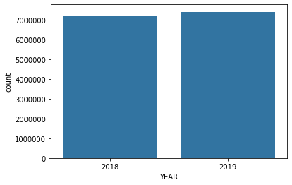

```python
#Looking at the number of flights for each year
clr = sns.color_palette()[0]
sns.countplot(data=df,x='YEAR',color=clr);
```

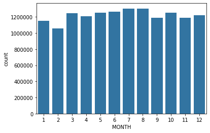

```python
#Looking at the number of flights for each month regardless of year
sns.countplot(data=df,x='MONTH',color=clr);
```

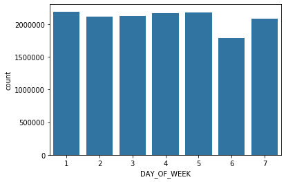

```python
#Looking at the number of flights for each weekday
sns.countplot(data=df,x='DAY_OF_WEEK',color=clr);
```

**Exploring the distribution of Flight Durations**

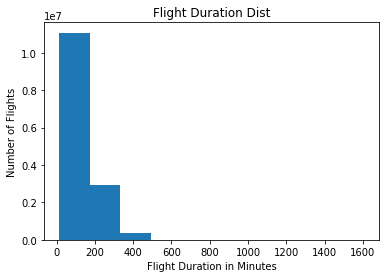

```python
plt.hist(data=df,x='ACTUAL_ELAPSED_TIME')
plt.title('Flight Duration Dist')
plt.xlabel('Flight Duration in Minutes')
plt.ylabel('Number of Flights');
```

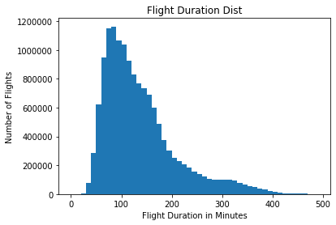

```python
#adjusting the bins and axis limit for better representation
bins=np.arange(0,500,10)
plt.hist(data=df,x='ACTUAL_ELAPSED_TIME',bins=bins)
plt.title('Flight Duration Dist')
plt.xlabel('Flight Duration in Minutes')
plt.ylabel('Number of Flights');
```

**Exploring the flight cancellation Reasons**

```
There were 251509 Cancelled Flights  in 2018-19 distributed as follows:
```

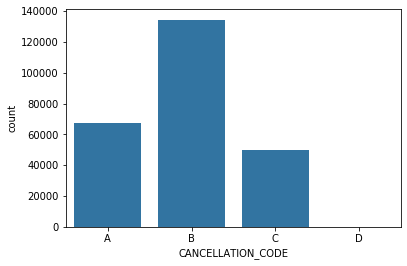

```python
#All cancelled flights regardless of year
cancellation_order=['A','B','C','D']
print("There were "+str(df.CANCELLATION_CODE.count()) +" Cancelled Flights  in 2018-19 distributed as follows:")
sns.countplot(data=df,x='CANCELLATION_CODE',color=clr,order=cancellation_order);
```

```python
#although it looks lilke there are no D (Security) cancellations,
#there are actually few but are overshadowed by the size of the y scale
df.CANCELLATION_CODE.value_counts()
```

```
B    134261
A     67338
C     49847
D        63
Name: CANCELLATION_CODE, dtype: int64
```

**Exploring Flight delay durations**

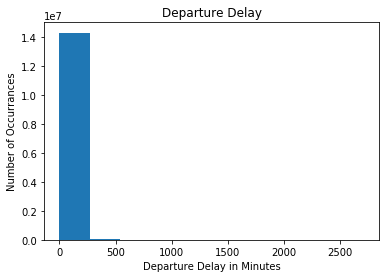

```python
plt.hist(data=df,x='DEP_DELAY_NEW')
plt.title('Departure Delay')
plt.xlabel('Departure Delay in Minutes')
plt.ylabel('Number of Occurrances');
```

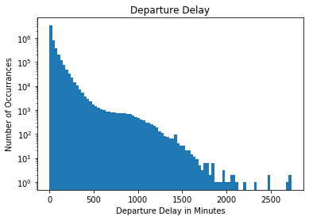

```python
#The x axis is too large, we will have to limit it and reduce the bin sizes with a log scale
bins=np.arange(1,df.DEP_DELAY_NEW.max()+30,30) #bin start at 0 to exlude non-delays
plt.hist(data=df,x='DEP_DELAY_NEW',bins=bins)
plt.title('Departure Delay')
plt.xlabel('Departure Delay in Minutes')
plt.ylabel('Number of Occurrances')
plt.yscale('log');
```

**Creating similar Chart but for Arrival Delays**

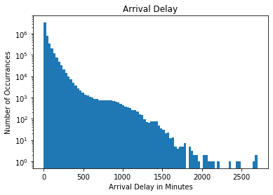

```python
bins=np.arange(1,df.ARR_DELAY_NEW.max()+30,30)
plt.hist(data=df,x='ARR_DELAY_NEW',bins=bins)
plt.title('Arrival Delay')
plt.xlabel('Arrival Delay in Minutes')
plt.ylabel('Number of Occurrances')
plt.yscale('log');
```

**Looking at top flight operators**

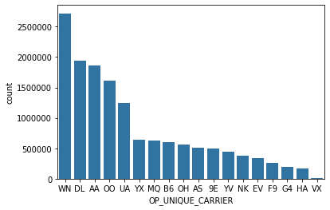

```python
top_airline=df['OP_UNIQUE_CARRIER'].value_counts().index
sns.countplot(data=df,x='OP_UNIQUE_CARRIER',color=clr,order=top_airline);
```

### Discuss the distribution(s) of your variable(s) of interest. Were there any unusual points? Did you need to perform any transformations?

**Flight Times Data**:

- Yearly Comparision: Seems like there were more flights in 2019 than 2018. Let's take a look at the number of flights per month (total for both years)
- Monthly Comparision: Some month appear to have fewer flights. This can be related to the number of days in the month (e.g. February is 28/29, while July and August are 31 days)
- Day of the week comparision: From a fist look Saturday appear to have lower flight numbers, this could be due to the fact that Saturday is the first day of the weekend, folllowed by higher flight numebrs on Sunday.

**Flight Duration and Cancellation Data**:

- Duration: The flight duration is skewed to the right, with most if the flights being 150 minutes (2.5 hours) or shorter. This would be interesting to see who operates such flights.
- Cancellation: Most of the flight cancellations are due to "B" (Weather) reasons forllowed by "A" (Carrier) reasons. It would be interesting to see when do these cancellations occur.

**Flight Delays**:

- Departure Delay: The departure delays appear to be right skewed (which is reassuring), howerver there is a significant delays in some flights.
- Arrival Delay: Again, The arrival delay is skewed to the right, with a pattern that is almost identical to the Departure delay, which is expected. It would be interesting to see the relationship between the Departure and Arrival delays.

**Flight Operators**:

- The number of flights by WN (SouthWest Airlines) is significantly exceeding the other carriers in this database, followed by known big airlines such as American Airlines and DElata. It's interesting since SouthWest is a low-cost carrier with short flights in nature. It would be interesting to look at the relationship between the carrier and flight times.

### Of the features you investigated, were there any unusual distributions? Did you perform any operations on the data to tidy, adjust, or change the form of the data? If so, why did you do this?

No transformation was needed at this stage since the data is fairly clean. The only thing I had to do was to reduce the range of the bins in some graphs due to outliers stretching the x axis.

## Bivariate Exploration

After looking at the previous data, we would need to explore some of them in bivaraite way in order to get some a better idea on the dataset.

**First I will look at the correlation between the departure and arrival delay**

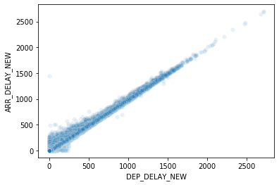

```python
sns.scatterplot(data=df,x='DEP_DELAY_NEW',y='ARR_DELAY_NEW',alpha=0.1);
```

**Next I will look at the relationship between the month and flight duration**

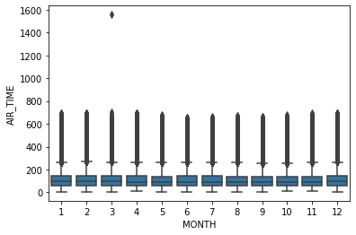

```python
sns.boxplot(data=df,x='MONTH',y='AIR_TIME',color=clr);
```

The outlayer in March is making the chart unreadable. I will have to exclude flight durations over 800 to clean this.

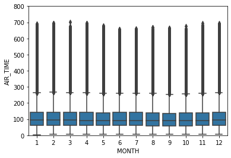

```python
h=sns.boxplot(data=df,x='MONTH',y='AIR_TIME',color=clr);
h.set(ylim=(0,800));
```

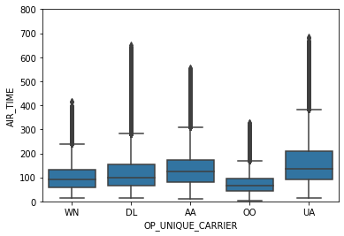

```python
h=sns.boxplot(data=df,x='OP_UNIQUE_CARRIER',y='AIR_TIME',color=clr,order=top_airline);
h.set(ylim=(0,800),xlim=(-0.5,4.5));
```

**Let's look at the correlation between distance and flight time**

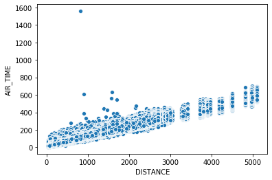

```python
sns.scatterplot(data=df,x='DISTANCE',y='AIR_TIME');
```

Again, there is one outlier that we should eliminate, in addition to introducing alpha value for transparency.

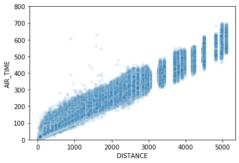

```python
h=sns.scatterplot(data=df,x='DISTANCE',y='AIR_TIME',alpha=0.1);
h.set(ylim=(0,800));
```

**Looking at the cancellation numbers across years and months**

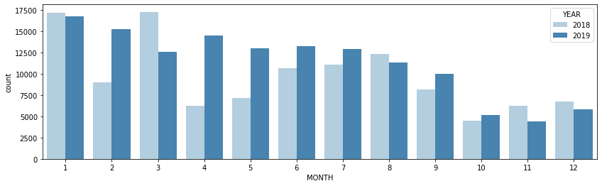

```python
cancelled=df.query('CANCELLED==1') #filtering tothe cancelled numbers only
plt.figure(figsize=(14, 4))
sns.countplot(data = cancelled, x = 'MONTH', hue = 'YEAR', palette = 'Blues');
```

### Talk about some of the relationships you observed in this part of the investigation. How did the feature(s) of interest vary with other features in the dataset?

- **Delay Correlations**: As assummed, there is a strong positive correlation between the two delay features. However the delay relationship does not apear to be a 1:1 relationship since the impact seems to be lower on longer flights rather than shorter ones. The clustering on the left is an indicator of the right skewed patteren identified earlier.
- **Flight Duration Monthly Distribution**: All months appear to have the similar flight durtion (Elapsed Time) distribution, with exception to one odd outlier in March. However,all have outliers outside the Quartile Range. This could be due to the overwhelming number of short flights by low cost airlines as shown in the Univariate analysis.
- **Flight Duration for top 5 airlines**: The flight duration of the top 5 airlines look interesting, since there are some airlines like WN (Southwest) and OO (Skywest) with a tight flight duration distribution in comparision to the other airlines (Delta, American Airlines, and United Airlines). It would be interesting to further examine the top five airlines in terms of other factors such as flight delay, and cancellation by month.
- **Correlation between physical distance and airtime**: The relationship is obviously strong and postitive. However, interestingly, the airtime in the sample seem to vary widely between flights with similar distances. There are also some observable gaps in some distance ranges between the 3000 and 5000 miles mark.
- **Flight Cancellation Across Months/Years**: The chart showed interesting pattern in cancellation for the two year sample we have. There is a high cancellation in both years in specific months such January (due to snow perhaps?), and June-August. Some months do vary between the years which is interesting, it may indicate special events during that specific year. It would be interesting to look at different plots for every cancellation type.

### Did you observe any interesting relationships between the other features (not the main feature(s) of interest)?

There are some interesting observations as explained in the section above, such as flight duration and airline, and relationship between the physical distance and actual airtime.

## Multivariate Exploration

We will further explore the items looked at in the Bivariate exploration section, to try to get more details about the dataset

**Flight Cancellation Across Months/Years in Relation to Cancellation Type**

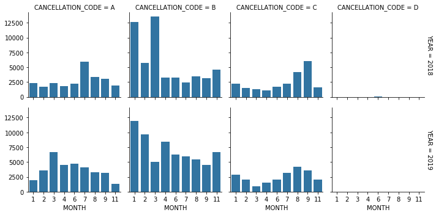

```python
g = sns.FacetGrid(data = cancelled, col = 'CANCELLATION_CODE', row = 'YEAR', size = 2.5,
                margin_titles = True,col_order=('A','B','C','D'))
g.map(sns.countplot,'MONTH');
```

**Flight Distance-Duration Plot Across the Years for Top 5 Airlines by Traffic**

```python
#creating a new dataframe only for the top five airliners.
airlines=('WN','DL','AA','OO','UA')
top_5=df.query('OP_UNIQUE_CARRIER in @airlines')
```

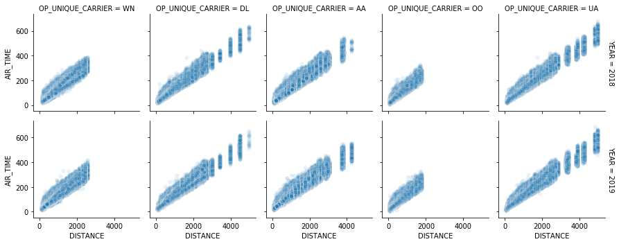

```python
g = sns.FacetGrid(data = top_5, col = 'OP_UNIQUE_CARRIER', row = 'YEAR', height = 2.5,
                margin_titles = True,col_order=airlines)
g.map(sns.scatterplot,'DISTANCE','AIR_TIME',alpha=0.1);
```

### Talk about some of the relationships you observed in this part of the investigation. Were there features that strengthened each other in terms of looking at your feature(s) of interest?

**Flight Distance-Duration Plot Across the Years for Top 5 Airlines by Traffic**: Both years have almost identical pattern. The chart showed the way the airlines operate in the US. we could see how Southwest distance is limited to approx 3000 miles, while SkyWest airlines is even shorter, approx 2000 miles. This could be related to the fleet type they operate with.